# Peer-graded Assignment: Prediction Assignment Writeup

Mehul Arora

October 18, 2020

#Background

It is possible to collect a lot of data by using devices like Jawbone, FuelBand, and Fitbit. The data can be about personal activity relatively inexpensively. The measurements are takein by enthusiasts who regularly to improve their health, to find patterns in their behavior. It can be possible becauseor they are tech enthusiasts. An intergral that people regularly do is quantify how much of that activity they usually do, but they rarely quantify how good they are in it. The goal will be to use data from accelerometers on the belt, forearm, arm, and dumbell of 6 participants in this project. They were asked to perform barbell lifts correctly and incorrectly in 5 different ways. More information is available from the website here: http://web.archive.org/web/20161224072740/http:/groupware.les.inf.puc-rio.br/har (see the section on the Weight Lifting Exercise Dataset).

#Objective

Predict the manner in which they did the exercise is the goal of the project. This is the “classe” variable in the training set. You may use any of the other variables to predict with. Then a report has to be created to describe how the model is being built, how you used cross validation, what you think the expected out of sample error is, and why you made the choices you did. You will also use your prediction model to predict 20 different test cases.

#Data

The data for training of this project is:

https://d396qusza40orc.cloudfront.net/predmachlearn/pml-training.csv

The test data is,

https://d396qusza40orc.cloudfront.net/predmachlearn/pml-testing.csv

#Load the data

```r
library(caret)
library(Hmisc)
```

```r
library(corrplot)
library(e1071)
```

First we download our data and we read them in R.

```r
set.seed(2343)
trainLink <-"https://d396qusza40orc.cloudfront.net/predmachlearn/pml-training.csv"
testLink <- "https://d396qusza40orc.cloudfront.net/predmachlearn/pml-testing.csv"
train <- "./data/train.csv"
quiz  <- "./data/quiz.csv"
if (!file.exists("./data")) {
  dir.create("./data")
}
if (!file.exists(train)) {
  download.file(trainLink, destfile = train, method = "curl")
}
if (!file.exists(quiz)) {
  download.file(testLink, destfile = quiz, method = "curl")
}
rm(trainLink)
rm(testLink)
```

```r
set.seed(2343)
summary(train)
```

```
##    Length     Class      Mode
##         1 character character
```

```r
str(train)
```

```
##  chr "./data/train.csv"
```

#Clenings

```r
set.seed(2343)
train = read.csv("./data/train.csv", na.strings=c("#DIV/0!"))
train.nZV <- nearZeroVar(train)
train<-train[ , -train.nZV]
variables <- colnames(train[colSums(is.na(train)) == 0])
data1<- train[variables]
working.data <- data1[ , -(1:6)]
dim(working.data)
```

```
## [1] 19622    53
```

#Data partition and correlation

The original daaset is seperated into a training set and a testing set for cross validation. We choose 70% of our original data to be the training set and 30% the testing set.

The correlation between the variables is checked:

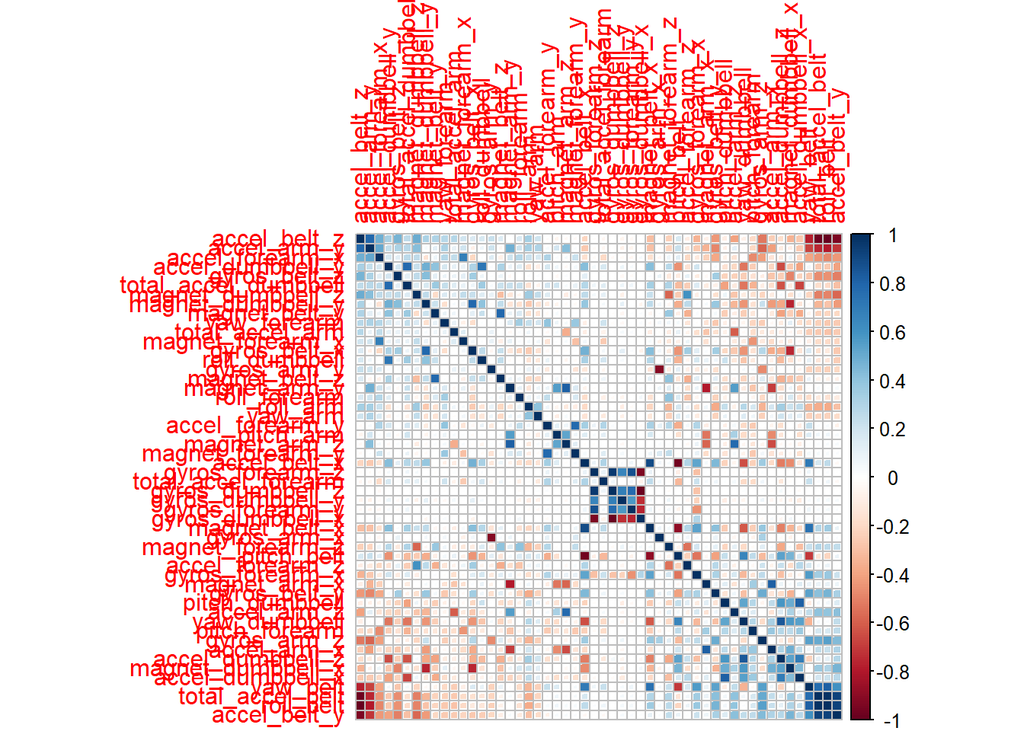

```r
set.seed(2343)
inTrain <- createDataPartition(y=working.data$classe, p=0.7, list=FALSE )
training <- working.data[inTrain,]
testing <- working.data[-inTrain,]
M <- cor(training[ , -53])
corrplot(M, order = "FPC", method = "square")
```

Variables that are highly correlated appear with darker colour (red or blue). Most of the input variables have weak correlation (if any). Therefore we will proceed with the modeling but, have a few different prediction models.

#Model selection

1. Support Vector Machine:

```r
set.seed(2343)
fit1 <- svm(classe ~ ., data = training)
predict1 <- predict(fit1, newdata = testing)
confusionMatrix(predict1, testing$classe)
```

```
## Confusion Matrix and Statistics
##
##           Reference
## Prediction    A    B    C    D    E
##          A 1662   90    3    2    0
##          B    6 1017   38    2   10
##          C    4   31  965   97   32
##          D    0    0   17  859   26
##          E    2    1    3    4 1014
##
## Overall Statistics
##
##                Accuracy : 0.9375
##                  95% CI : (0.931, 0.9435)
##     No Information Rate : 0.2845
##     P-Value [Acc > NIR] : < 2.2e-16
##
##                   Kappa : 0.9208
##
##  Mcnemar's Test P-Value : < 2.2e-16
##
## Statistics by Class:
##
##                      Class: A Class: B Class: C Class: D Class: E
## Sensitivity            0.9928   0.8929   0.9405   0.8911   0.9372
## Specificity            0.9774   0.9882   0.9662   0.9913   0.9979
## Pos Pred Value         0.9459   0.9478   0.8547   0.9523   0.9902
## Neg Pred Value         0.9971   0.9746   0.9872   0.9789   0.9860
## Prevalence             0.2845   0.1935   0.1743   0.1638   0.1839
## Detection Rate         0.2824   0.1728   0.1640   0.1460   0.1723
## Detection Prevalence   0.2986   0.1823   0.1918   0.1533   0.1740
## Balanced Accuracy      0.9851   0.9405   0.9534   0.9412   0.9675
```

```r
set.seed(2343)
TCgbm <- trainControl(method = "cv", 5)
fit2  <- train(classe ~ ., data = training, method = "rf",
                  trControl = TCgbm, verbose = FALSE)
predict2<- predict(fit2, newdata = testing)
confusionMatrix(predict2, testing$classe)
```

```
## Confusion Matrix and Statistics
##
##           Reference
## Prediction    A    B    C    D    E
##          A 1673    6    0    0    0
##          B    1 1132   13    0    0
##          C    0    1 1009   22    0
##          D    0    0    4  942    2
##          E    0    0    0    0 1080
##
## Overall Statistics
##
##                Accuracy : 0.9917
##                  95% CI : (0.989, 0.9938)
##     No Information Rate : 0.2845
##     P-Value [Acc > NIR] : < 2.2e-16
##
##                   Kappa : 0.9895
##
##  Mcnemar's Test P-Value : NA
##
## Statistics by Class:
##
##                      Class: A Class: B Class: C Class: D Class: E
## Sensitivity            0.9994   0.9939   0.9834   0.9772   0.9982
## Specificity            0.9986   0.9971   0.9953   0.9988   1.0000
## Pos Pred Value         0.9964   0.9878   0.9777   0.9937   1.0000
## Neg Pred Value         0.9998   0.9985   0.9965   0.9955   0.9996
## Prevalence             0.2845   0.1935   0.1743   0.1638   0.1839
## Detection Rate         0.2843   0.1924   0.1715   0.1601   0.1835
## Detection Prevalence   0.2853   0.1947   0.1754   0.1611   0.1835
## Balanced Accuracy      0.9990   0.9955   0.9893   0.9880   0.9991
```

3. Random Forest:

```r
set.seed(2343)
TCrf <- trainControl(method = "cv", 5)
fit3  <- train(classe ~ ., data = training, method = "rf",
                  trControl = TCrf, verbose = FALSE)
predict3 <- predict(fit3, newdata = testing)
confusionMatrix(predict3, testing$classe)
```

```
## Confusion Matrix and Statistics
##
##           Reference
## Prediction    A    B    C    D    E
##          A 1673    6    0    0    0
##          B    1 1132   13    0    0
##          C    0    1 1009   22    0
##          D    0    0    4  942    2
##          E    0    0    0    0 1080
##
## Overall Statistics
##
##                Accuracy : 0.9917
##                  95% CI : (0.989, 0.9938)
##     No Information Rate : 0.2845
##     P-Value [Acc > NIR] : < 2.2e-16
##
##                   Kappa : 0.9895
##
##  Mcnemar's Test P-Value : NA
##
## Statistics by Class:
##
##                      Class: A Class: B Class: C Class: D Class: E
## Sensitivity            0.9994   0.9939   0.9834   0.9772   0.9982
## Specificity            0.9986   0.9971   0.9953   0.9988   1.0000
## Pos Pred Value         0.9964   0.9878   0.9777   0.9937   1.0000
## Neg Pred Value         0.9998   0.9985   0.9965   0.9955   0.9996
## Prevalence             0.2845   0.1935   0.1743   0.1638   0.1839
## Detection Rate         0.2843   0.1924   0.1715   0.1601   0.1835
## Detection Prevalence   0.2853   0.1947   0.1754   0.1611   0.1835
## Balanced Accuracy      0.9990   0.9955   0.9893   0.9880   0.9991
```

#Out-of-sample error

```r
set.seed(2343)
out.of.sample.error = function(values, predicted) {
  sum(predicted != values) / length(values)
}
out.of.sample.error(testing$classe, predict3)
```

```
## [1] 0.008326253
```